#### $\color{skyblue}{\textrm{- Categorical Variables}}$

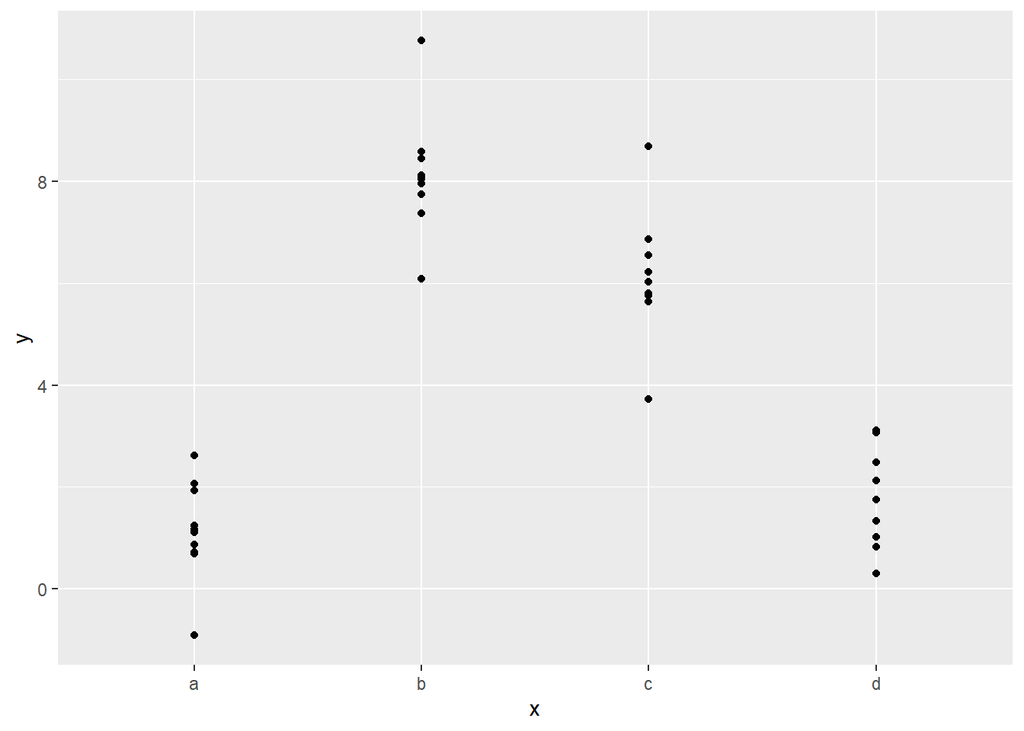

```r
sim2 %>%
  ggplot(aes(x = x, y = y)) +
  geom_point()
```

```r
#Equation values
model2 <- lm(y ~ x, data = sim2)

broom::tidy(model2)
```

| term | estimate | std.error | statistic | p.value |
| --- | --- | --- | --- | --- |
| (Intercept) | 1.1521664 | 0.3474903 | 3.315680 | 0.0020949 |
| xb | 6.9638728 | 0.4914255 | 14.170761 | 0.0000000 |
| xc | 4.9750241 | 0.4914255 | 10.123660 | 0.0000000 |
| xd | 0.7588142 | 0.4914255 | 1.544108 | 0.1313082 |

This essentially creates dummy variables where the coefficient is the mean of the variable. (Note that one value is dropped and its “coefficient” is the intercept; the other coefficients are in reference to this value.)

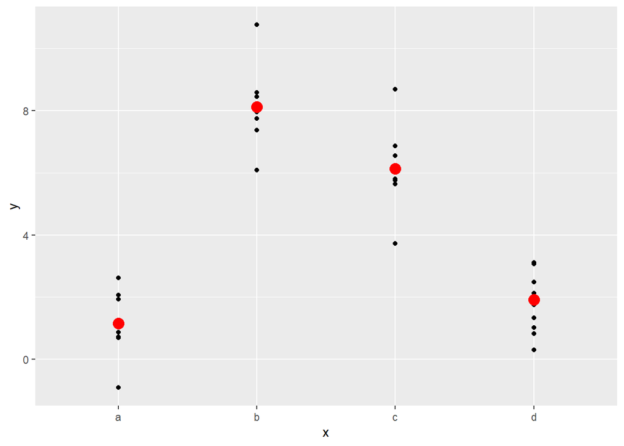

```r
#Visualized
sim2 %>%
  add_predictions(model2) %>%
  ggplot() +
  geom_point(aes(x = x, y = y)) +
  geom_point(aes(x = x, y = pred), color = "red", size = 4)
```

How far away are the predictions from the observed values? (Note that the average of the residual will always be 0.)

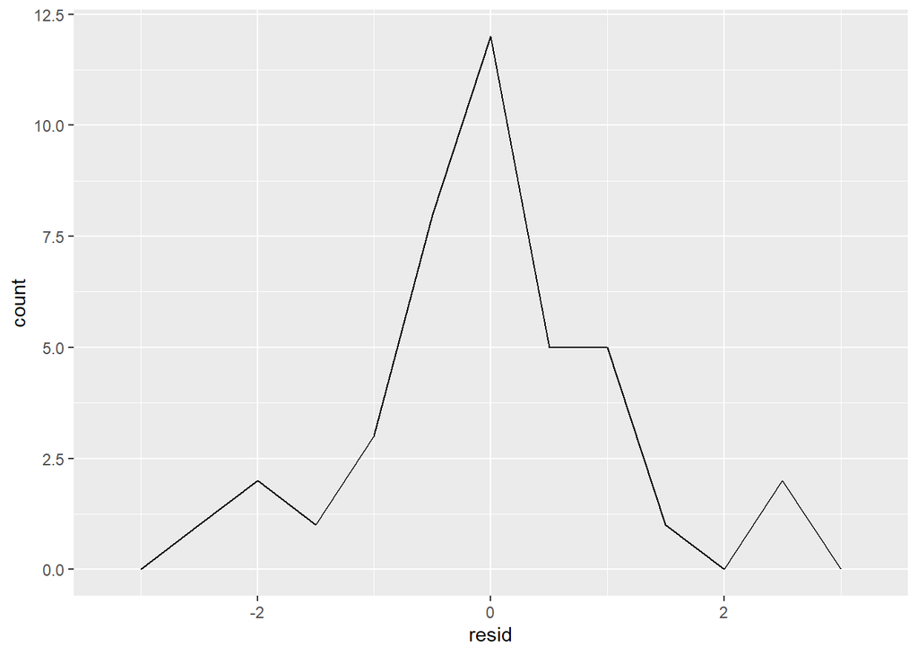

```r
sim2 %>%
  add_residuals(model2) %>%
  ggplot(aes(resid)) +
  geom_freqpoly(binwidth = 0.5)
```

Are there any patterns in the distribution of the residuals, suggesting the model is better or worse at predicting certain ranges?

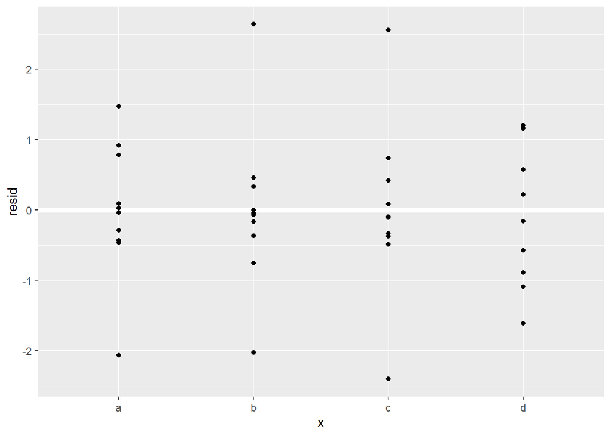

```r
sim2 %>%
  add_residuals(model2) %>%
  ggplot(aes(x, resid)) +
  geom_ref_line(h = 0) +
  geom_point()
```

```r
#Statistics
broom::glance(model2)
```

| r.squared | adj.r.squared | sigma | statistic | p.value | df | logLik | AIC | BIC | deviance | df.residual | nobs |
| --- | --- | --- | --- | --- | --- | --- | --- | --- | --- | --- | --- |
| 0.8851864 | 0.8756186 | 1.098861 | 92.51722 | 0 | 3 | -58.42129 | 126.8426 | 135.287 | 43.46982 | 36 | 40 |

#### $\color{skyblue}{\textrm{- Multiple Variables}}$

Adding additional terms to the equation is as easy as `+`:

```r
model_add <- lm(y ~ x1 + x2, data = sim4)

broom::tidy(model_add)
```

| term | estimate | std.error | statistic | p.value |
| --- | --- | --- | --- | --- |
| (Intercept) | 0.035460 | 0.1218412 | 0.2910343 | 0.7712282 |
| x1 | 1.821666 | 0.1908884 | 9.5430931 | 0.0000000 |
| x2 | -2.782516 | 0.1908884 | -14.5766585 | 0.0000000 |

However, there could be an interaction between the variables that, if captured, woukd produce a more accurate model. Adding an additional term and an interaction between terms is done using `*`. (Note that `*` includes both `x1 * x2` as well as `x1 + x2`.)

*Continuous + Categorical*

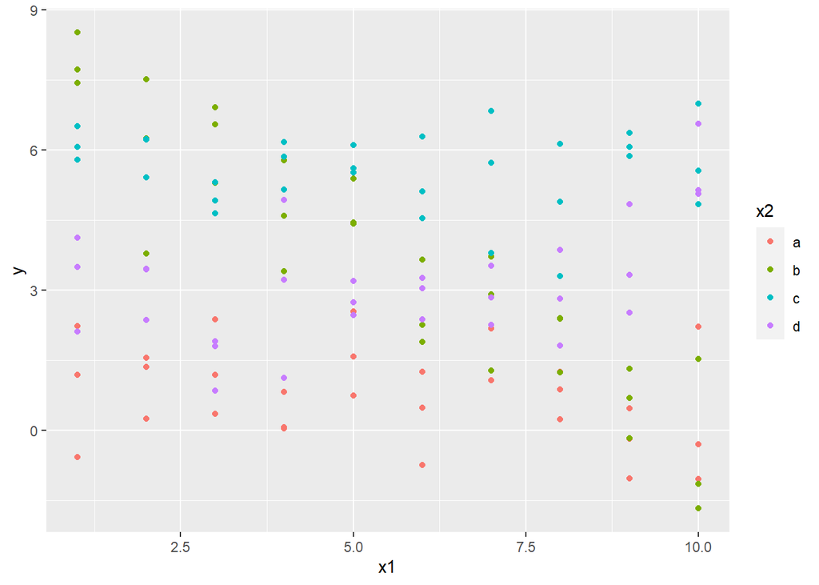

```r
sim3 %>%
  ggplot(aes(x = x1, y = y, color = x2)) +
  geom_point()
```

```r
model_add <- lm(y ~ x1 + x2, data = sim3)

broom::tidy(model_add)
```

| term | estimate | std.error | statistic | p.value |
| --- | --- | --- | --- | --- |
| (Intercept) | 1.8716659 | 0.3873752 | 4.831662 | 4.20e-06 |
| x1 | -0.1967378 | 0.0487081 | -4.039114 | 9.72e-05 |
| x2b | 2.8878108 | 0.3957068 | 7.297855 | 0.00e+00 |
| x2c | 4.8057359 | 0.3957068 | 12.144688 | 0.00e+00 |
| x2d | 2.3595867 | 0.3957068 | 5.962967 | 0.00e+00 |

```r
model_interact <- lm(y ~ x1 * x2, data = sim3)

broom::tidy(model_interact)
```

| term | estimate | std.error | statistic | p.value |
| --- | --- | --- | --- | --- |
| (Intercept) | 1.3012427 | 0.4039981 | 3.2209128 | 0.0016729 |
| x1 | -0.0930244 | 0.0651102 | -1.4287233 | 0.1558668 |
| x2b | 7.0693799 | 0.5713396 | 12.3733416 | 0.0000000 |
| x2c | 4.4308953 | 0.5713396 | 7.7552743 | 0.0000000 |
| x2d | 0.8345512 | 0.5713396 | 1.4606920 | 0.1468997 |
| x1:x2b | -0.7602853 | 0.0920797 | -8.2568164 | 0.0000000 |
| x1:x2c | 0.0681528 | 0.0920797 | 0.7401505 | 0.4607574 |
| x1:x2d | 0.2772792 | 0.0920797 | 3.0112952 | 0.0032156 |

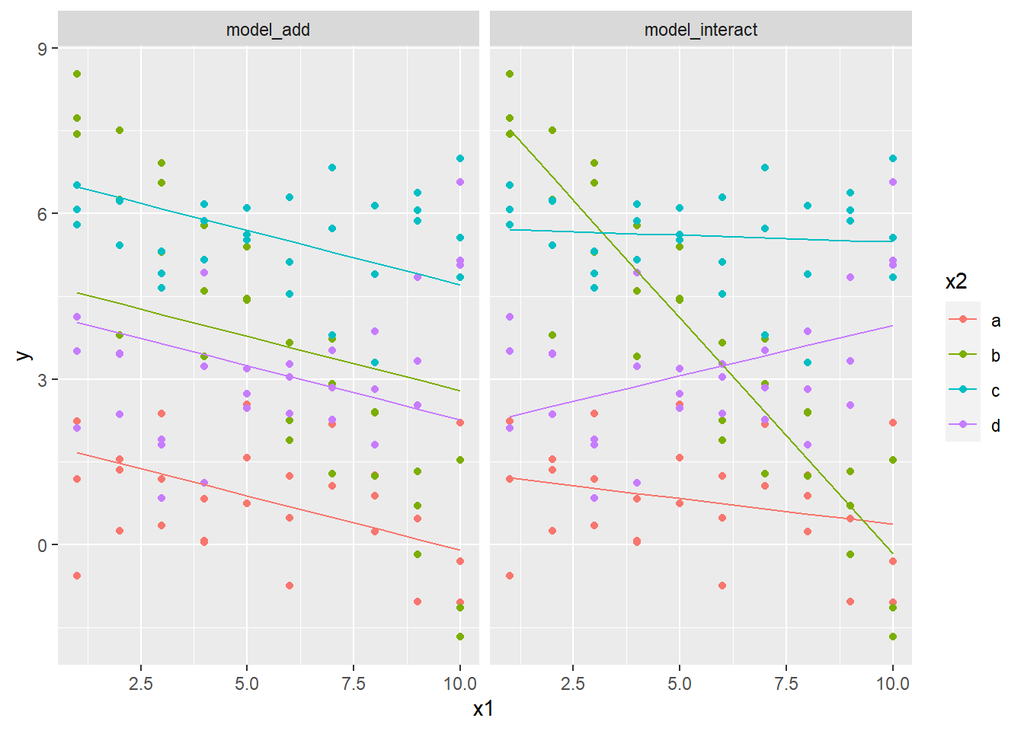

```r
sim3 %>%
  gather_predictions(model_add, model_interact) %>%
  ggplot() +
  geom_point(aes(x = x1, y = y, color = x2)) +
  geom_line(aes(x = x1, y = pred, color = x2)) +
  facet_wrap(~model)
```

Note that the model that uses `+` has the same slope for each line, but different intercepts. The model that uses `*` has a different slope and intercept for each line.

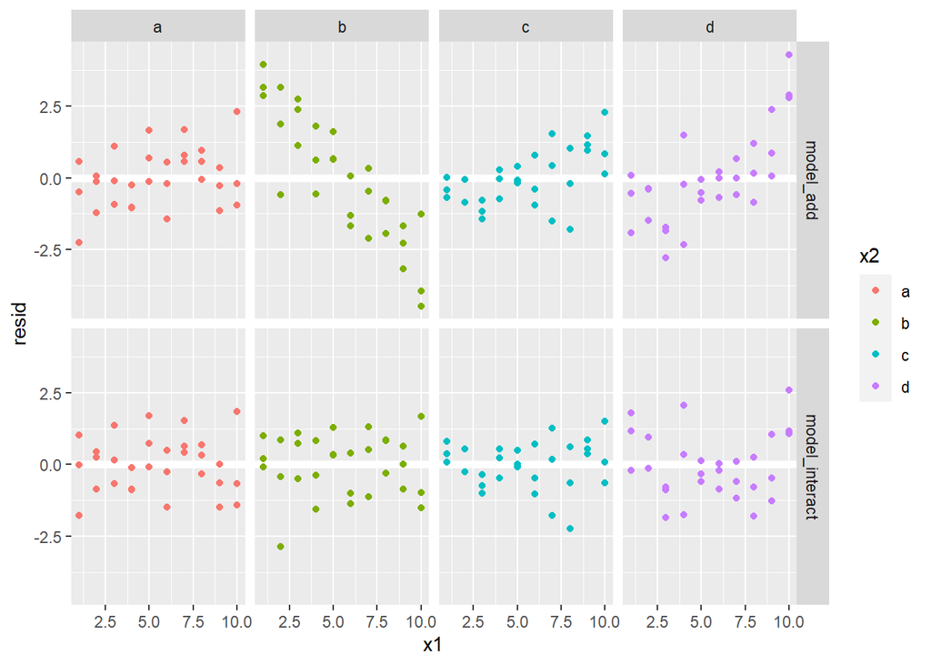

```r
sim3 %>%
  gather_residuals(model_add, model_interact) %>%
  ggplot(aes(x = x1, y = resid, color = x2)) +
  geom_ref_line(h = 0) +
  geom_point() +
  facet_grid(model ~ x2)
```

The residuals for the simple addition model are non-random whereas the interaction model seems more randomly distributed. The interaction model is likely the better model here.

```r
#Statistics
broom::glance(model_add) %>%
  bind_rows(broom::glance(model_interact)) %>%
  mutate(model = c("model_add", "model_interact")) %>%
  select(model, everything())
```

| model | r.squared | adj.r.squared | sigma | statistic | p.value | df | logLik | AIC | BIC | deviance | df.residual | nobs |
| --- | --- | --- | --- | --- | --- | --- | --- | --- | --- | --- | --- | --- |
| model_add | 0.5910569 | 0.5768328 | 1.532566 | 41.55318 | 0 | 4 | -218.9523 | 449.9045 | 466.6295 | 270.1072 | 115 | 120 |
| model_interact | 0.8220828 | 0.8109630 | 1.024322 | 73.92948 | 0 | 7 | -169.0168 | 356.0336 | 381.1210 | 117.5144 | 112 | 120 |

*Continuous + Continuous*

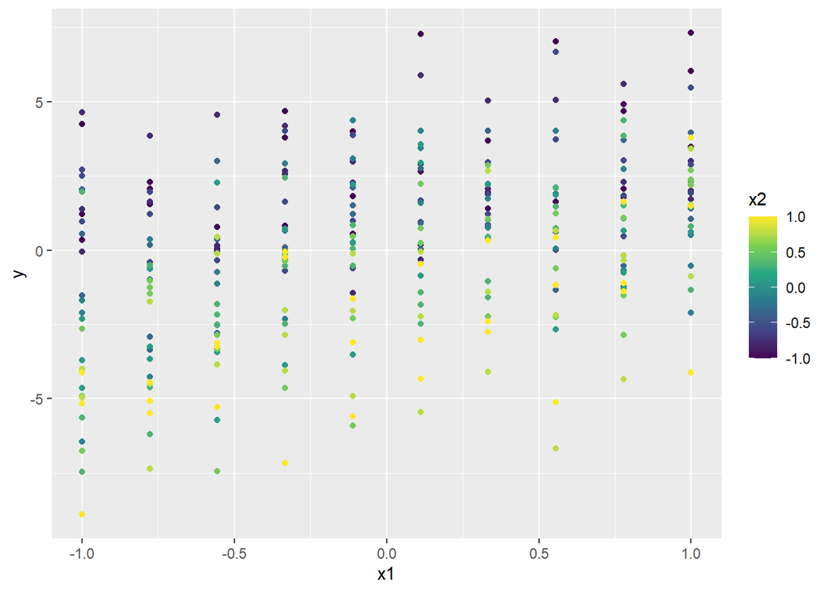

```r
sim4 %>%
  ggplot(aes(x = x1, y = y, color = x2)) +
  geom_point() +
  scale_color_viridis_c()
```

```r
model_add <- lm(y ~ x1 + x2, data = sim4)

broom::tidy(model_add)
```

| term | estimate | std.error | statistic | p.value |
| --- | --- | --- | --- | --- |
| (Intercept) | 0.035460 | 0.1218412 | 0.2910343 | 0.7712282 |
| x1 | 1.821666 | 0.1908884 | 9.5430931 | 0.0000000 |
| x2 | -2.782516 | 0.1908884 | -14.5766585 | 0.0000000 |

```r
model_interact <- lm(y ~ x1 * x2, data = sim4)

broom::tidy(model_interact)
```

| term | estimate | std.error | statistic | p.value |
| --- | --- | --- | --- | --- |
| (Intercept) | 0.0354600 | 0.1199455 | 0.295634 | 0.7677169 |
| x1 | 1.8216661 | 0.1879185 | 9.693917 | 0.0000000 |
| x2 | -2.7825155 | 0.1879185 | -14.807036 | 0.0000000 |
| x1:x2 | 0.9522788 | 0.2944117 | 3.234515 | 0.0013564 |

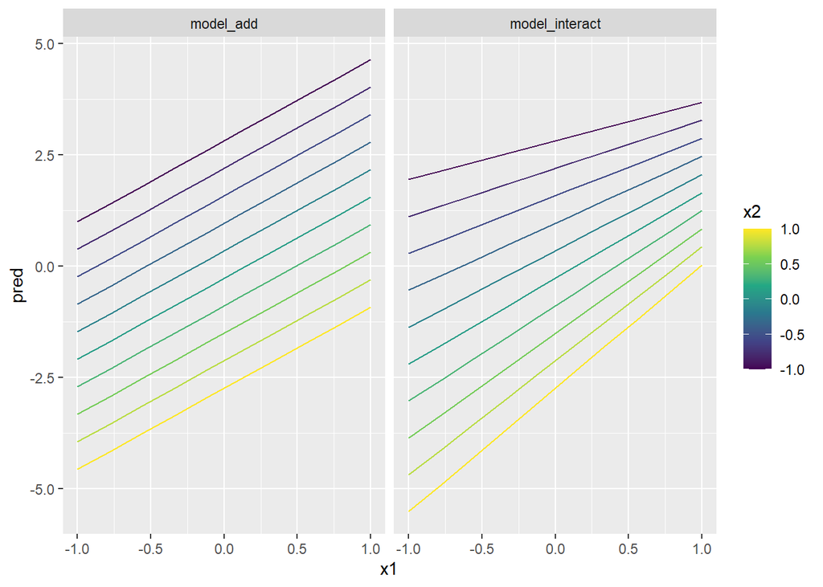

```r
sim4 %>%
  gather_predictions(model_add, model_interact) %>%
  ggplot(aes(x1, pred, colour = x2, group = x2)) +
  geom_line() +
  facet_wrap(~ model) +
  scale_color_viridis_c()
```

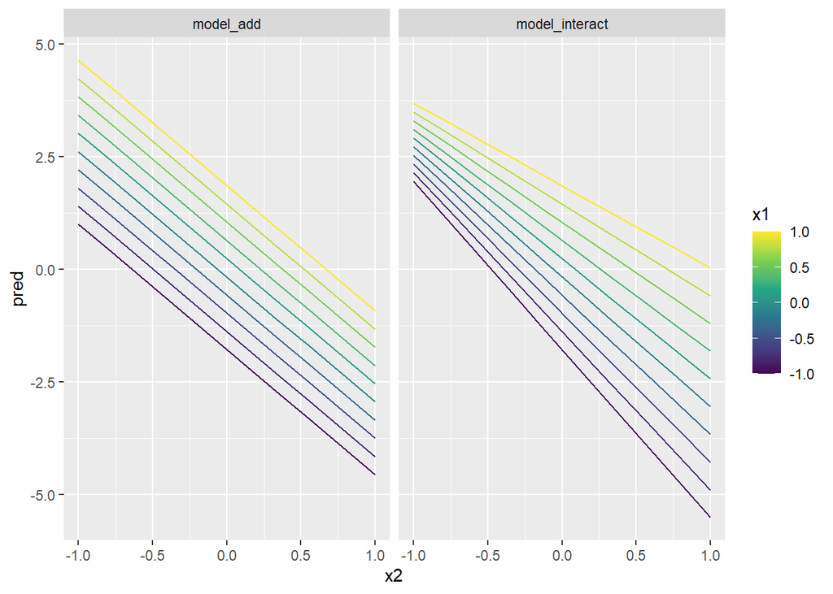

```r
sim4 %>%
  gather_predictions(model_add, model_interact) %>%
  ggplot(aes(x2, pred, colour = x1, group = x1)) +
  geom_line() +
  facet_wrap(~ model) +
  scale_color_viridis_c()
```

Create a grid of combinations from the min to the max of each x variable (if desired you can also trim a certain percent, e.g. `trim = 0.1`, or expand beyond the min/min, e.g. `expand = 0.1`) :

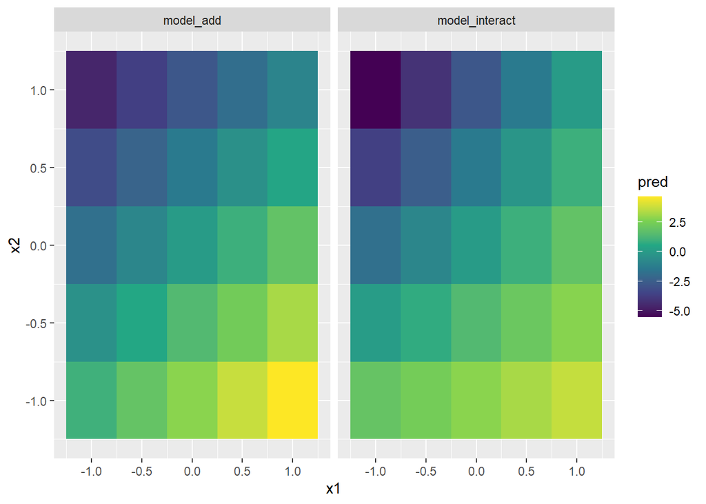

```r
sim4 %>%
  data_grid(x1 = seq_range(x1, n = 5, pretty = TRUE),
            x2 = seq_range(x2, n = 5, pretty = TRUE)) %>%
  gather_predictions(model_add, model_interact) %>%
  ggplot(aes(x1, x2)) +
  geom_tile(aes(fill = pred)) +
  facet_wrap(~ model) +
  scale_fill_viridis_c()
```

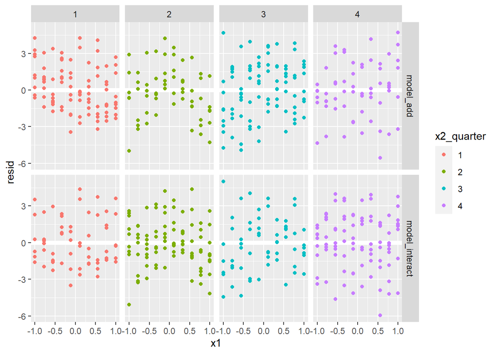

```r
sim4 %>%
  gather_residuals(model_add, model_interact) %>%
  mutate(x2_quarter = ntile(x2, 4) %>% factor()) %>%
  ggplot(aes(x = x1, y = resid, color = x2_quarter)) +
  geom_ref_line(h = 0) +
  geom_point() +
  facet_grid(model ~ x2_quarter)
```

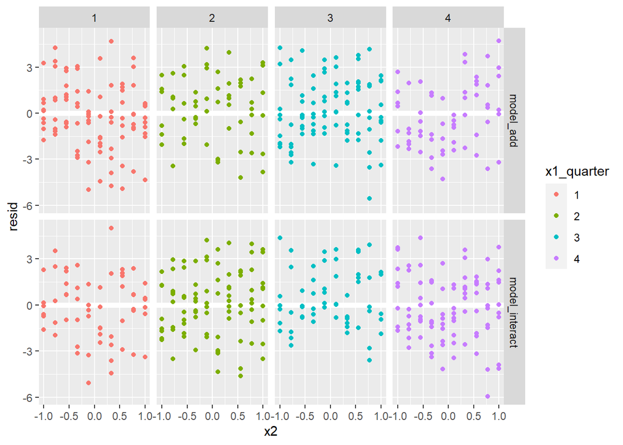

```r
sim4 %>%
  gather_residuals(model_add, model_interact) %>%
  mutate(x1_quarter = ntile(x1, 4) %>% factor()) %>%
  ggplot(aes(x = x2, y = resid, color = x1_quarter)) +
  geom_ref_line(h = 0) +
  geom_point() +
  facet_grid(model ~ x1_quarter)
```

The difference in distributions here is subtle, though the interaction model is slightly better.

```r
#Statistics
broom::glance(model_add) %>%
  bind_rows(broom::glance(model_interact)) %>%
  mutate(model = c("model_add", "model_interact")) %>%
  select(model, everything())
```

| model | r.squared | adj.r.squared | sigma | statistic | p.value | df | logLik | AIC | BIC | deviance | df.residual | nobs |
| --- | --- | --- | --- | --- | --- | --- | --- | --- | --- | --- | --- | --- |
| model_add | 0.505453 | 0.5021227 | 2.110351 | 151.7748 | 0 | 2 | -648.2303 | 1304.461 | 1319.276 | 1322.714 | 297 | 300 |
| model_interact | 0.522336 | 0.5174948 | 2.077517 | 107.8941 | 0 | 3 | -643.0201 | 1296.040 | 1314.559 | 1277.559 | 296 | 300 |

#### $\color{skyblue}{\textrm{- Transformations}}$

It’s possible to transform elements of the equation directly in the call using:

- `log()`
- `sqrt()`
- `I(x ^ n)`

```r
lm(log(y) ~ sqrt(x1) + I(x2 ^ 2), data = sim4)
```

# $\color{darkblue}{\textbf{Unsupervised}}$

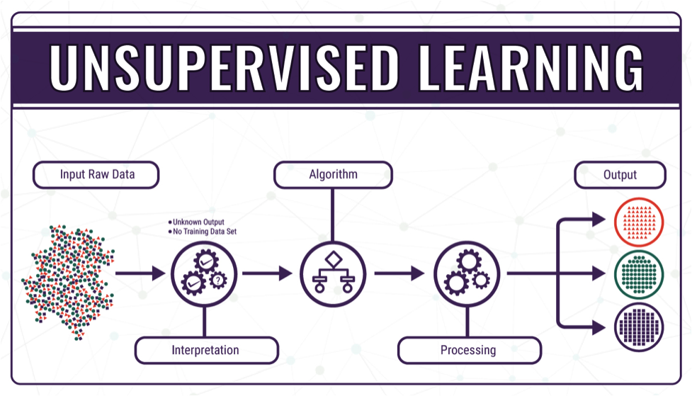

# $\color{darkblue}{\textbf{Multiple Models}}$

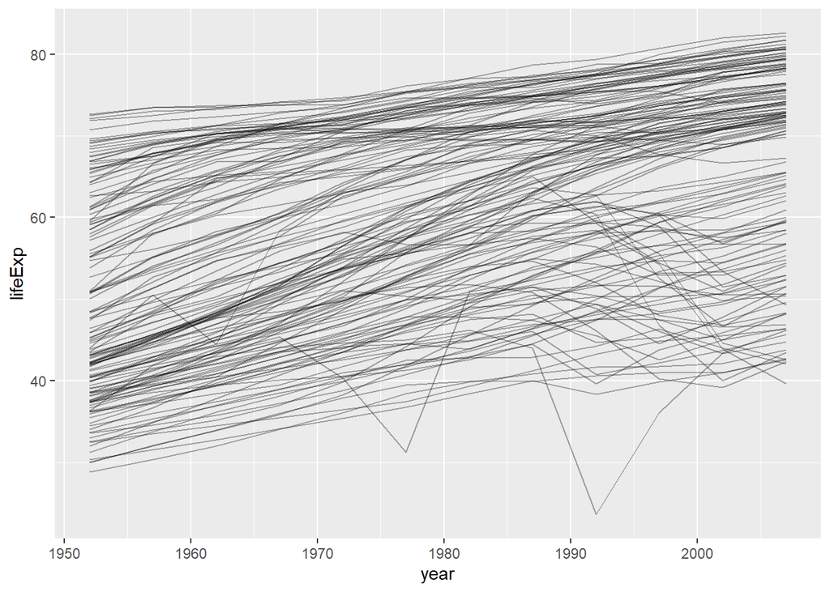

```r
gapminder %>%
  ggplot(aes(x = year, y = lifeExp, group = country)) +
  geom_line(alpha = 0.33)
```

Analysis of a single country:

```r
us <- gapminder %>%
  filter(country == "United States")

us_mod <- lm(lifeExp ~ year, data = us)

broom::tidy(us_mod)
```

| term | estimate | std.error | statistic | p.value |
| --- | --- | --- | --- | --- |
| (Intercept) | -291.0844923 | 13.7773959 | -21.12769 | 0 |
| year | 0.1841692 | 0.0069598 | 26.46196 | 0 |

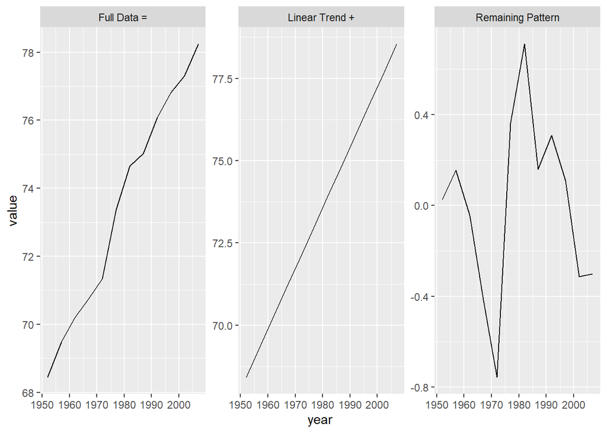

```r
us %>%
  add_predictions(us_mod) %>%
  add_residuals(us_mod) %>%
  select(year, lifeExp, pred, resid) %>%
  gather(-year, key = model, value = value) %>%
  mutate(model = recode(model,
                        "lifeExp" = "Full Data =",
                        "pred" = "Linear Trend +",
                        "resid" = "Remaining Pattern")) %>%
  ggplot(aes(x = year, y = value)) +
  geom_line() +
  facet_wrap(~ model, scales = "free_y")
```

Nest by country to run the model for each. (This produces a dataframe with a row for each group, country, and a column with the data.)

```r
by_country <- gapminder %>%
  group_by(country, continent) %>%
  nest()

by_country %>% (head)
```

| country | continent | data |
| --- | --- | --- |
| Afghanistan | Asia | 1.952000e+03, 1.957000e+03, 1.962000e+03, 1.967000e+03, 1.972000e+03, 1.977000e+03, 1.982000e+03, 1.987000e+03, 1.992000e+03, 1.997000e+03, 2.002000e+03, 2.007000e+03, 2.880100e+01, 3.033200e+01, 3.19… |
| Albania | Europe | 1952.000, 1957.000, 1962.000, 1967.000, 1972.000, 1977.000, 1982.000, 1987.000, 1992.000, 1997.000, 2002.000, 2007.000, 55.230, 59.280, 64.820, 66.220, 67.690, 68.930, 70.420, 72.000, 71.581, 72.950, … |
| Algeria | Africa | 1952.000, 1957.000, 1962.000, 1967.000, 1972.000, 1977.000, 1982.000, 1987.000, 1992.000, 1997.000, 2002.000, 2007.000, 43.077, 45.685, 48.303, 51.407, 54.518, 58.014, 61.368, 65.799, 67.744, 69.152, … |
| Angola | Africa | 1952.000, 1957.000, 1962.000, 1967.000, 1972.000, 1977.000, 1982.000, 1987.000, 1992.000, 1997.000, 2002.000, 2007.000, 30.015, 31.999, 34.000, 35.985, 37.928, 39.483, 39.942, 39.906, 40.647, 40.963, … |
| Argentina | Americas | 1952.000, 1957.000, 1962.000, 1967.000, 1972.000, 1977.000, 1982.000, 1987.000, 1992.000, 1997.000, 2002.000, 2007.000, 62.485, 64.399, 65.142, 65.634, 67.065, 68.481, 69.942, 70.774, 71.868, 73.275, … |
| Australia | Oceania | 1952.000, 1957.000, 1962.000, 1967.000, 1972.000, 1977.000, 1982.000, 1987.000, 1992.000, 1997.000, 2002.000, 2007.000, 69.120, 70.330, 70.930, 71.100, 71.930, 73.490, 74.740, 76.320, 77.560, 78.830, … |

```r
by_country$data[[1]] %>% head()
```

| year | lifeExp | pop | gdpPercap |
| --- | --- | --- | --- |
| 1952 | 28.801 | 8425333 | 779.4453 |
| 1957 | 30.332 | 9240934 | 820.8530 |
| 1962 | 31.997 | 10267083 | 853.1007 |
| 1967 | 34.020 | 11537966 | 836.1971 |
| 1972 | 36.088 | 13079460 | 739.9811 |
| 1977 | 38.438 | 14880372 | 786.1134 |

Fit the model:

```r
country_model <- function(df) {
  lm(lifeExp ~ year, data = df)
}

by_country <- by_country %>%
  mutate(model = map(data, country_model),
         preds = map2(data, model, add_predictions),
         resids = map2(data, model, add_residuals))

by_country$model[[1]]
```

```
Call:
lm(formula = lifeExp ~ year, data = df)

Coefficients:
(Intercept)         year
  -507.5343       0.2753
```

Unnest the findings:

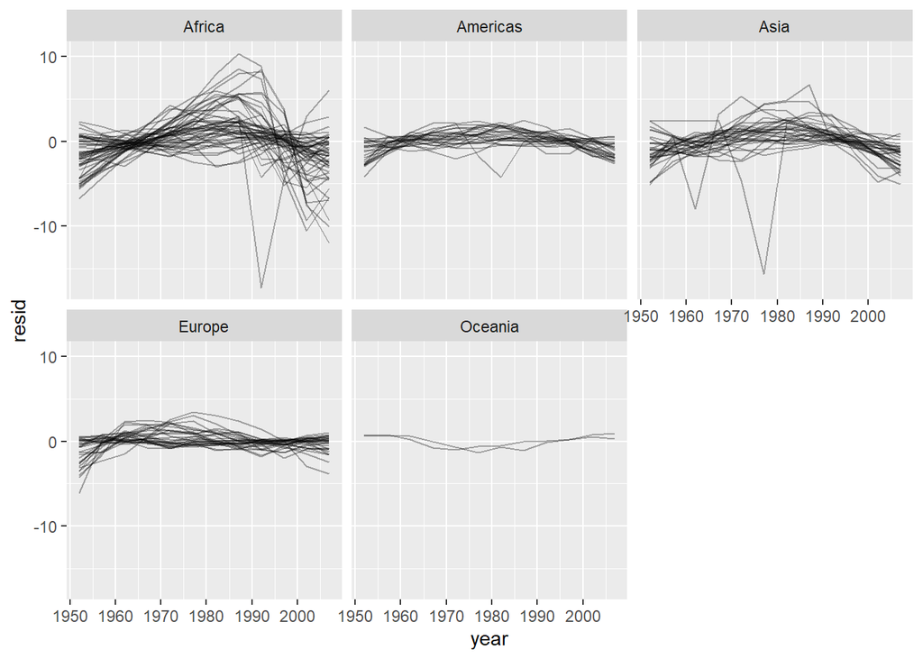

```r
by_country %>%
  unnest(c(country, resids)) %>%
  ggplot(aes(year, resid, group = country)) +
    geom_line(alpha = 1 / 3) +
    facet_wrap(~continent)
```

It looks like we’ve missed some mild patterns. There’s also something interesting going on in Africa: we see some very large residuals which suggests our model isn’t fitting so well there.

```r
#Statistics
stats_by_country <- by_country %>%
  mutate(glance = map(model, broom::glance)) %>%
  unnest(glance)

stats_by_country %>%
  head()
```

| country | continent | data | model | preds | resids | r.squared | adj.r.squared | sigma | statistic | p.value | df | logLik | AIC | BIC | deviance | df.residual | nobs |
| --- | --- | --- | --- | --- | --- | --- | --- | --- | --- | --- | --- | --- | --- | --- | --- | --- | --- |
| Afghanistan | Asia | 1.952000e+03, 1.957000e+03, 1.962000e+03, 1.967000e+03, 1.972000e+03, 1.977000e+03, 1.982000e+03, 1.987000e+03, 1.992000e+03, 1.997000e+03, 2.002000e+03, 2.007000e+03, 2.880100e+01, 3.033200e+01, 3.19… | -507.5343, 0.2753287, -1.106295, -0.9519382, -0.6635816, -0.01722494, 0.6741317, 1.647488, 1.686845, 1.278202, 0.7535583, -0.5340851, -1.544728, -1.222372, -129.8305, 16.46226, -0.3108827, 0.2892301, … | 1.952000e+03, 1.957000e+03, 1.962000e+03, 1.967000e+03, 1.972000e+03, 1.977000e+03, 1.982000e+03, 1.987000e+03, 1.992000e+03, 1.997000e+03, 2.002000e+03, 2.007000e+03, 2.880100e+01, 3.033200e+01, 3.19… | 1.952000e+03, 1.957000e+03, 1.962000e+03, 1.967000e+03, 1.972000e+03, 1.977000e+03, 1.982000e+03, 1.987000e+03, 1.992000e+03, 1.997000e+03, 2.002000e+03, 2.007000e+03, 2.880100e+01, 3.033200e+01, 3.19… | 0.9477123 | 0.9424835 | 1.2227880 | 181.24941 | 1.0e-07 | 1 | -18.346935 | 42.693870 | 44.148590 | 14.9521045 | 10 | 12 |
| Albania | Europe | 1952.000, 1957.000, 1962.000, 1967.000, 1972.000, 1977.000, 1982.000, 1987.000, 1992.000, 1997.000, 2002.000, 2007.000, 55.230, 59.280, 64.820, 66.220, 67.690, 68.930, 70.420, 72.000, 71.581, 72.950, … | -594.0725, 0.3346832, -3.999128, -1.622544, 2.24404, 1.970624, 1.767207, 1.333791, 1.150375, 1.056959, -1.035457, -1.339873, -0.312289, -1.213705, -237.0586, 20.01115, 3.248124, 2.926981, 2.675838, 2.… | 1.952000e+03, 1.957000e+03, 1.962000e+03, 1.967000e+03, 1.972000e+03, 1.977000e+03, 1.982000e+03, 1.987000e+03, 1.992000e+03, 1.997000e+03, 2.002000e+03, 2.007000e+03, 5.523000e+01, 5.928000e+01, 6.48… | 1.952000e+03, 1.957000e+03, 1.962000e+03, 1.967000e+03, 1.972000e+03, 1.977000e+03, 1.982000e+03, 1.987000e+03, 1.992000e+03, 1.997000e+03, 2.002000e+03, 2.007000e+03, 5.523000e+01, 5.928000e+01, 6.48… | 0.9105778 | 0.9016355 | 1.9830615 | 101.82901 | 1.5e-06 | 1 | -24.149036 | 54.298071 | 55.752791 | 39.3253302 | 10 | 12 |
| Algeria | Africa | 1952.000, 1957.000, 1962.000, 1967.000, 1972.000, 1977.000, 1982.000, 1987.000, 1992.000, 1997.000, 2002.000, 2007.000, 43.077, 45.685, 48.303, 51.407, 54.518, 58.014, 61.368, 65.799, 67.744, 69.152, … | -1067.859, 0.5692797, -0.2979744, -0.536373, -0.7647716, -0.5071702, -0.2425688, 0.4070326, 0.914634, 2.499235, 1.597837, 0.1594382, -0.8449604, -2.384359, -204.4865, 34.03798, -0.6280719, -0.4013136,… | 1.952000e+03, 1.957000e+03, 1.962000e+03, 1.967000e+03, 1.972000e+03, 1.977000e+03, 1.982000e+03, 1.987000e+03, 1.992000e+03, 1.997000e+03, 2.002000e+03, 2.007000e+03, 4.307700e+01, 4.568500e+01, 4.83… | 1.952000e+03, 1.957000e+03, 1.962000e+03, 1.967000e+03, 1.972000e+03, 1.977000e+03, 1.982000e+03, 1.987000e+03, 1.992000e+03, 1.997000e+03, 2.002000e+03, 2.007000e+03, 4.307700e+01, 4.568500e+01, 4.83… | 0.9851172 | 0.9836289 | 1.3230064 | 661.91709 | 0.0e+00 | 1 | -19.292214 | 44.584427 | 46.039147 | 17.5034589 | 10 | 12 |
| Angola | Africa | 1952.000, 1957.000, 1962.000, 1967.000, 1972.000, 1977.000, 1982.000, 1987.000, 1992.000, 1997.000, 2002.000, 2007.000, 30.015, 31.999, 34.000, 35.985, 37.928, 39.483, 39.942, 39.906, 40.647, 40.963, … | -376.5048, 0.2093399, -2.111654, -1.174353, -0.2200524, 0.7182483, 1.614549, 2.12285, 1.53515, 0.452451, 0.1467517, -0.5839476, -1.590647, -0.9093462, -131.2323, 12.5167, 0.3574398, 1.24968, 2.099921,… | 1.952000e+03, 1.957000e+03, 1.962000e+03, 1.967000e+03, 1.972000e+03, 1.977000e+03, 1.982000e+03, 1.987000e+03, 1.992000e+03, 1.997000e+03, 2.002000e+03, 2.007000e+03, 3.001500e+01, 3.199900e+01, 3.40… | 1.952000e+03, 1.957000e+03, 1.962000e+03, 1.967000e+03, 1.972000e+03, 1.977000e+03, 1.982000e+03, 1.987000e+03, 1.992000e+03, 1.997000e+03, 2.002000e+03, 2.007000e+03, 3.001500e+01, 3.199900e+01, 3.40… | 0.8878146 | 0.8765961 | 1.4070091 | 79.13818 | 4.6e-06 | 1 | -20.030928 | 46.061857 | 47.516577 | 19.7967471 | 10 | 12 |
| Argentina | Americas | 1952.000, 1957.000, 1962.000, 1967.000, 1972.000, 1977.000, 1982.000, 1987.000, 1992.000, 1997.000, 2002.000, 2007.000, 62.485, 64.399, 65.142, 65.634, 67.065, 68.481, 69.942, 70.774, 71.868, 73.275, … | -389.6063, 0.2317084, -0.2034359, 0.5520221, 0.1364802, -0.5300618, -0.2576037, -0.0001456876, 0.3023124, -0.0242296, -0.08877156, 0.1596865, 0.06614452, -0.1123974, -239.2323, 13.85415, 0.09303993, -… | 1.952000e+03, 1.957000e+03, 1.962000e+03, 1.967000e+03, 1.972000e+03, 1.977000e+03, 1.982000e+03, 1.987000e+03, 1.992000e+03, 1.997000e+03, 2.002000e+03, 2.007000e+03, 6.248500e+01, 6.439900e+01, 6.51… | 1.952000e+03, 1.957000e+03, 1.962000e+03, 1.967000e+03, 1.972000e+03, 1.977000e+03, 1.982000e+03, 1.987000e+03, 1.992000e+03, 1.997000e+03, 2.002000e+03, 2.007000e+03, 6.248500e+01, 6.439900e+01, 6.51… | 0.9955681 | 0.9951249 | 0.2923072 | 2246.36635 | 0.0e+00 | 1 | -1.173933 | 8.347866 | 9.802586 | 0.8544349 | 10 | 12 |
| Australia | Oceania | 1952.000, 1957.000, 1962.000, 1967.000, 1972.000, 1977.000, 1982.000, 1987.000, 1992.000, 1997.000, 2002.000, 2007.000, 69.120, 70.330, 70.930, 71.100, 71.930, 73.490, 74.740, 76.320, 77.560, 78.830, … | -376.1163, 0.2277238, 0.7194872, 0.7908683, 0.2522494, -0.7163695, -1.024988, -0.6036072, -0.4922261, -0.05084499, 0.05053613, 0.1819172, 0.5832984, 0.3096795, -258.6399, 13.6159, -0.002715871, -0.929… | 1.952000e+03, 1.957000e+03, 1.962000e+03, 1.967000e+03, 1.972000e+03, 1.977000e+03, 1.982000e+03, 1.987000e+03, 1.992000e+03, 1.997000e+03, 2.002000e+03, 2.007000e+03, 6.912000e+01, 7.033000e+01, 7.09… | 1.952000e+03, 1.957000e+03, 1.962000e+03, 1.967000e+03, 1.972000e+03, 1.977000e+03, 1.982000e+03, 1.987000e+03, 1.992000e+03, 1.997000e+03, 2.002000e+03, 2.007000e+03, 6.912000e+01, 7.033000e+01, 7.09… | 0.9796477 | 0.9776125 | 0.6206086 | 481.34586 | 0.0e+00 | 1 | -10.208677 | 26.417353 | 27.872073 | 3.8515501 | 10 | 12 |

Check on the worst performing models:

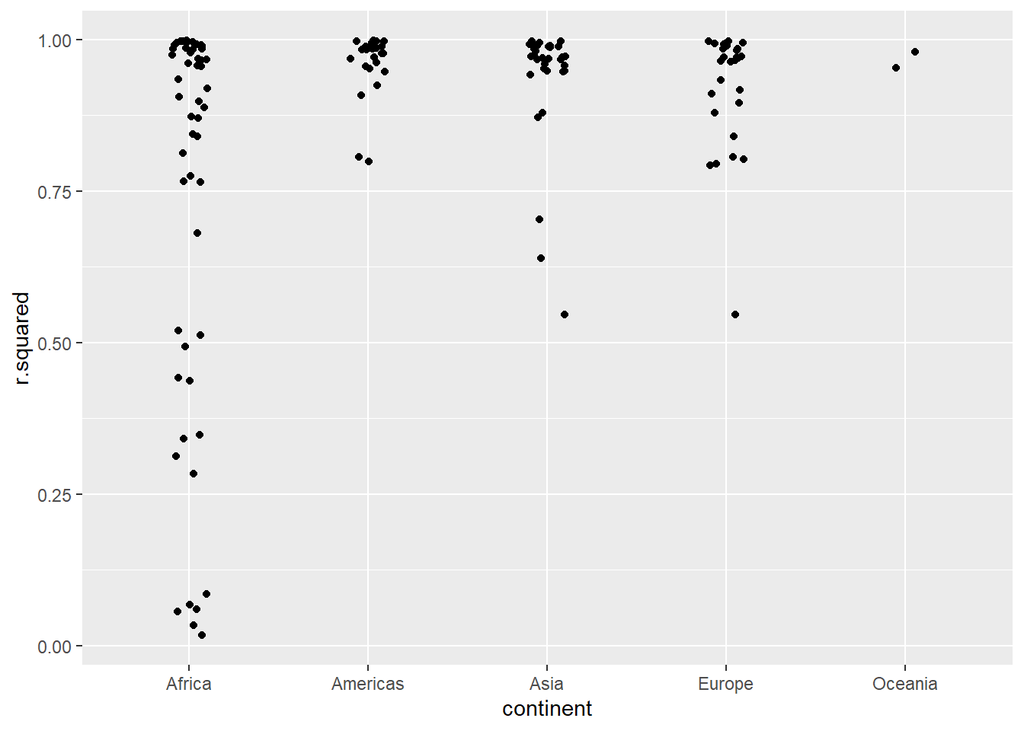

```r
stats_by_country %>%
  ggplot(aes(x = continent, y = r.squared)) +
  geom_jitter(width = 0.1)
```

```r
stats_by_country %>%
  filter(r.squared < 0.1) %>%
  arrange(r.squared)
```

| country | continent | data | model | preds | resids | r.squared | adj.r.squared | sigma | statistic | p.value | df | logLik | AIC | BIC | deviance | df.residual | nobs |
| --- | --- | --- | --- | --- | --- | --- | --- | --- | --- | --- | --- | --- | --- | --- | --- | --- | --- |
| Rwanda | Africa | 1952.0000, 1957.0000, 1962.0000, 1967.0000, 1972.0000, 1977.0000, 1982.0000, 1987.0000, 1992.0000, 1997.0000, 2002.0000, 2007.0000, 40.0000, 41.5000, 43.0000, 44.1000, 44.6000, 45.0000, 46.2180, 44.02… | 132.205, -0.04583147, -2.741949, -1.012791, 0.716366, 2.045523, 2.774681, 3.403838, 4.850995, 2.882153, -17.30969, -4.592533, 2.962625, 6.020782, -143.6964, -2.740323, 1.389955, 2.692936, 3.395916, 3.… | 1.952000e+03, 1.957000e+03, 1.962000e+03, 1.967000e+03, 1.972000e+03, 1.977000e+03, 1.982000e+03, 1.987000e+03, 1.992000e+03, 1.997000e+03, 2.002000e+03, 2.007000e+03, 4.000000e+01, 4.150000e+01, 4.30… | 1.952000e+03, 1.957000e+03, 1.962000e+03, 1.967000e+03, 1.972000e+03, 1.977000e+03, 1.982000e+03, 1.987000e+03, 1.992000e+03, 1.997000e+03, 2.002000e+03, 2.007000e+03, 4.000000e+01, 4.150000e+01, 4.30… | 0.0171596 | -0.0811244 | 6.558269 | 0.1745923 | 0.6848927 | 1 | -38.50205 | 83.00411 | 84.45883 | 430.1090 | 10 | 12 |
| Botswana | Africa | 1952.0000, 1957.0000, 1962.0000, 1967.0000, 1972.0000, 1977.0000, 1982.0000, 1987.0000, 1992.0000, 1997.0000, 2002.0000, 2007.0000, 47.6220, 49.6180, 51.5200, 53.2980, 56.0240, 59.3190, 61.4840, 63.62… | -65.49586, 0.06066853, -5.307115, -3.614458, -2.015801, -0.5411434, 1.881514, 4.873171, 6.734829, 8.569486, 7.389143, -3.103199, -9.328542, -5.537885, -189.1313, 3.627451, -0.4656616, 0.8496905, 3.113… | 1.952000e+03, 1.957000e+03, 1.962000e+03, 1.967000e+03, 1.972000e+03, 1.977000e+03, 1.982000e+03, 1.987000e+03, 1.992000e+03, 1.997000e+03, 2.002000e+03, 2.007000e+03, 4.762200e+01, 4.961800e+01, 5.15… | 1.952000e+03, 1.957000e+03, 1.962000e+03, 1.967000e+03, 1.972000e+03, 1.977000e+03, 1.982000e+03, 1.987000e+03, 1.992000e+03, 1.997000e+03, 2.002000e+03, 2.007000e+03, 4.762200e+01, 4.961800e+01, 5.15… | 0.0340234 | -0.0625743 | 6.112177 | 0.3522177 | 0.5660414 | 1 | -37.65673 | 81.31346 | 82.76818 | 373.5871 | 10 | 12 |
| Zimbabwe | Africa | 1.952000e+03, 1.957000e+03, 1.962000e+03, 1.967000e+03, 1.972000e+03, 1.977000e+03, 1.982000e+03, 1.987000e+03, 1.992000e+03, 1.997000e+03, 2.002000e+03, 2.007000e+03, 4.845100e+01, 5.046900e+01, 5.23… | 236.7982, -0.09302098, -6.770244, -4.287139, -1.933034, 0.1690711, 2.274176, 4.778281, 7.932386, 10.38549, 8.876596, -4.2263, -10.58119, -6.61809, -182.4306, -5.561846, -0.003763574, 1.916383, 3.83952… | 1.952000e+03, 1.957000e+03, 1.962000e+03, 1.967000e+03, 1.972000e+03, 1.977000e+03, 1.982000e+03, 1.987000e+03, 1.992000e+03, 1.997000e+03, 2.002000e+03, 2.007000e+03, 4.845100e+01, 5.046900e+01, 5.23… | 1.952000e+03, 1.957000e+03, 1.962000e+03, 1.967000e+03, 1.972000e+03, 1.977000e+03, 1.982000e+03, 1.987000e+03, 1.992000e+03, 1.997000e+03, 2.002000e+03, 2.007000e+03, 4.845100e+01, 5.046900e+01, 5.23… | 0.0562320 | -0.0381448 | 7.205431 | 0.5958240 | 0.4580290 | 1 | -39.63135 | 85.26271 | 86.71743 | 519.1823 | 10 | 12 |
| Zambia | Africa | 1952.000, 1957.000, 1962.000, 1967.000, 1972.000, 1977.000, 1982.000, 1987.000, 1992.000, 1997.000, 2002.000, 2007.000, 42.038, 44.077, 46.023, 47.768, 50.107, 51.386, 51.821, 50.821, 46.100, 40.238, … | 165.608, -0.06042517, -5.620026, -3.2789, -1.030774, 1.016352, 3.657478, 5.238604, 5.97573, 5.277855, 0.8589814, -4.700893, -5.443767, -1.950641, -159.336, -3.6129, 0.5290378, 2.4435, 4.951963, 6.4004… | 1.952000e+03, 1.957000e+03, 1.962000e+03, 1.967000e+03, 1.972000e+03, 1.977000e+03, 1.982000e+03, 1.987000e+03, 1.992000e+03, 1.997000e+03, 2.002000e+03, 2.007000e+03, 4.203800e+01, 4.407700e+01, 4.60… | 1.952000e+03, 1.957000e+03, 1.962000e+03, 1.967000e+03, 1.972000e+03, 1.977000e+03, 1.982000e+03, 1.987000e+03, 1.992000e+03, 1.997000e+03, 2.002000e+03, 2.007000e+03, 4.203800e+01, 4.407700e+01, 4.60… | 0.0598364 | -0.0341799 | 4.528713 | 0.6364471 | 0.4435318 | 1 | -34.05859 | 74.11717 | 75.57189 | 205.0924 | 10 | 12 |
| Swaziland | Africa | 1952.000, 1957.000, 1962.000, 1967.000, 1972.000, 1977.000, 1982.000, 1987.000, 1992.000, 1997.000, 2002.000, 2007.000, 41.407, 43.424, 44.992, 46.633, 49.552, 52.537, 55.561, 57.678, 58.474, 54.289, … | -139.1982, 0.09507483, -4.980859, -3.439233, -2.346607, -1.180981, 1.262645, 3.77227, 6.320896, 7.962522, 8.283148, 3.622774, -7.2726, -12.00397, -169.7494, 5.684648, -0.8847665, 0.1282624, 2.419291, … | 1.952000e+03, 1.957000e+03, 1.962000e+03, 1.967000e+03, 1.972000e+03, 1.977000e+03, 1.982000e+03, 1.987000e+03, 1.992000e+03, 1.997000e+03, 2.002000e+03, 2.007000e+03, 4.140700e+01, 4.342400e+01, 4.49… | 1.952000e+03, 1.957000e+03, 1.962000e+03, 1.967000e+03, 1.972000e+03, 1.977000e+03, 1.982000e+03, 1.987000e+03, 1.992000e+03, 1.997000e+03, 2.002000e+03, 2.007000e+03, 4.140700e+01, 4.342400e+01, 4.49… | 0.0682109 | -0.0249680 | 6.644091 | 0.7320419 | 0.4122530 | 1 | -38.65807 | 83.31614 | 84.77086 | 441.4395 | 10 | 12 |
| Lesotho | Africa | 1952.0000, 1957.0000, 1962.0000, 1967.0000, 1972.0000, 1977.0000, 1982.0000, 1987.0000, 1992.0000, 1997.0000, 2002.0000, 2007.0000, 42.1380, 45.0470, 47.7470, 48.4920, 49.7670, 52.2080, 55.0780, 57.18… | -139.1653, 0.09556573, -5.241026, -2.809854, -0.587683, -0.3205117, 0.4766597, 2.439831, 4.832002, 6.456174, 8.483345, 3.878516, -7.564312, -10.04314, -173.2296, 5.714, 0.8300106, 0.9897477, 1.679485,… | 1.952000e+03, 1.957000e+03, 1.962000e+03, 1.967000e+03, 1.972000e+03, 1.977000e+03, 1.982000e+03, 1.987000e+03, 1.992000e+03, 1.997000e+03, 2.002000e+03, 2.007000e+03, 4.213800e+01, 4.504700e+01, 4.77… | 1.952000e+03, 1.957000e+03, 1.962000e+03, 1.967000e+03, 1.972000e+03, 1.977000e+03, 1.982000e+03, 1.987000e+03, 1.992000e+03, 1.997000e+03, 2.002000e+03, 2.007000e+03, 4.213800e+01, 4.504700e+01, 4.77… | 0.0848564 | -0.0066580 | 5.933934 | 0.9272463 | 0.3582864 | 1 | -37.30158 | 80.60316 | 82.05788 | 352.1157 | 10 | 12 |

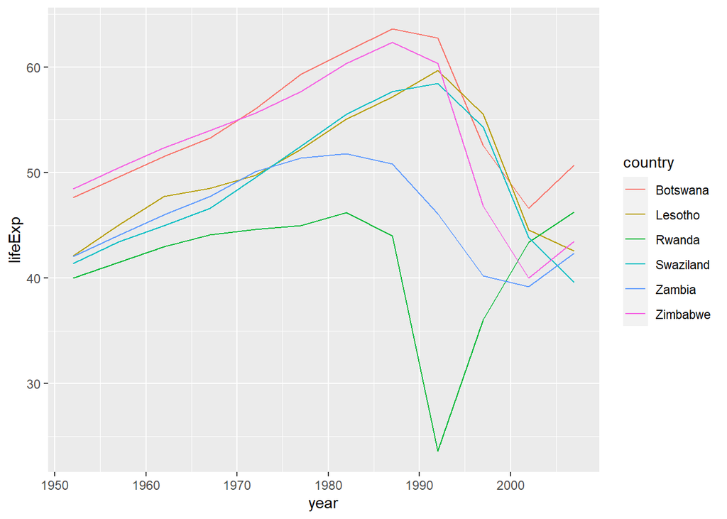

```r
gapminder %>%
  semi_join(stats_by_country %>%
              filter(r.squared < 0.1),
            by = "country") %>%
  ggplot(aes(x = year, y = lifeExp, color = country)) +
  geom_line()
```

We see two main effects here: the tragedies of the HIV/AIDS epidemic and the Rwandan genocide.

Return to R Page